# Machine Learning Intro

- Prediction based on data (learning from data).
- Types:
  - Supervised:
    - Regression
    - Classification
  - Unsupervised
  - Reinforcement Learning (RL)
- Here we provide an introduction to ML with a supervised problem.

## Data

- For applying ML we need (clean and processed) data.
- Imaginary store: data about temperature (ºC) and ice cream sales (€).
- The data we use for creating (training) models is called **training data**.

```python
df = pd.DataFrame({
    'temp (x)': [5, 8, 10, 12, 20, 23, 33, 35],
    'sales (y)': [200, 235, 210, 240, 420, 435, 560, 620]})
df
```

|  | temp (x) | sales (y) |
| --- | --- | --- |
| 0 | 5 | 200 |
| 1 | 8 | 235 |
| 2 | 10 | 210 |
| 3 | 12 | 240 |
| 4 | 20 | 420 |
| 5 | 23 | 435 |
| 6 | 33 | 560 |
| 7 | 35 | 620 |

- We use the temperature for predicting sales.
- Conventional names are:
  - `X` for referring to the **features**/attributes that help in the prediction (`temperature` in our case).
  - `y` for referring to the **target** attribute we want to predict (`sales` in our case).

```python
# temperature (ºC)
X = df[['temp (x)']].values

# sales (€)
y = df['sales (y)'].values
```

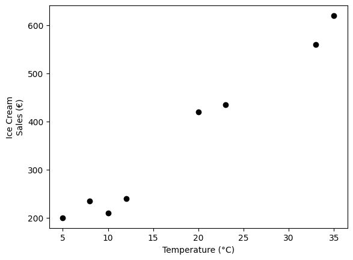

```python
plot_data(X, y)
plt.show()
```

## Linear Model

- Line of the form $f(x) = w_0 + w_1 * x$.
- E.g. $w_0 = 100$ and $w_1 = 14$.
- Our prediction of Ice cream sales is $\hat{y} = 100 + 14 * x$, where
  - $x$ is the temperature.
- We use $\hat{y}$ for referring to the prediction given by our function approximation.
- We use $y$ for referring to the real sales values in our data.

```python
# Model

w0 = 100
w1 = 14

# predicted y
y_pred = w0 + w1 * X
```

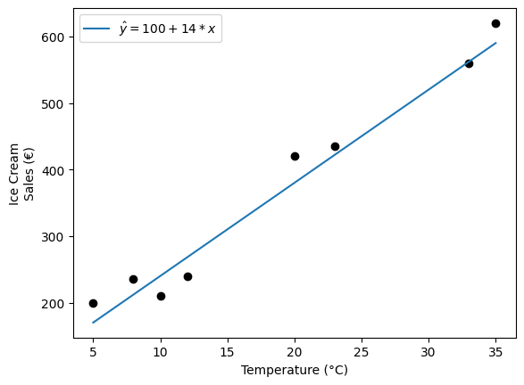

```python
# Model

plot_data(X, y)
plt.plot(X, y_pred, label="$\hat{y} = 100 + 14 * x$")
plt.legend()
plt.show()
```

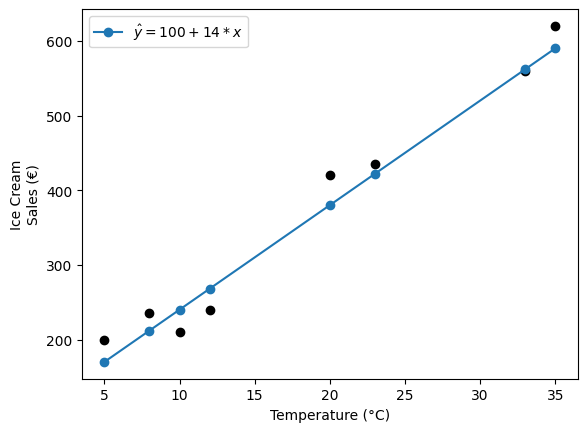

```python
# Predictions

plot_data(X, y)
plt.plot(X, y_pred, marker='o', label="$\hat{y} = 100 + 14 * x$")
plt.legend()
plt.show()
```

```python
df['sales_pred (ŷ)'] = y_pred
df
```

|  | temp (x) | sales (y) | sales_pred (ŷ) |
| --- | --- | --- | --- |
| 0 | 5 | 200 | 170 |
| 1 | 8 | 235 | 212 |
| 2 | 10 | 210 | 240 |
| 3 | 12 | 240 | 268 |
| 4 | 20 | 420 | 380 |
| 5 | 23 | 435 | 422 |
| 6 | 33 | 560 | 562 |
| 7 | 35 | 620 | 590 |

- Are our predictions good? It seems a reasonable model.
- But is this other model (orange) better or worse than our previous one (blue)?
- We need a way to quantify how good the predictions are.

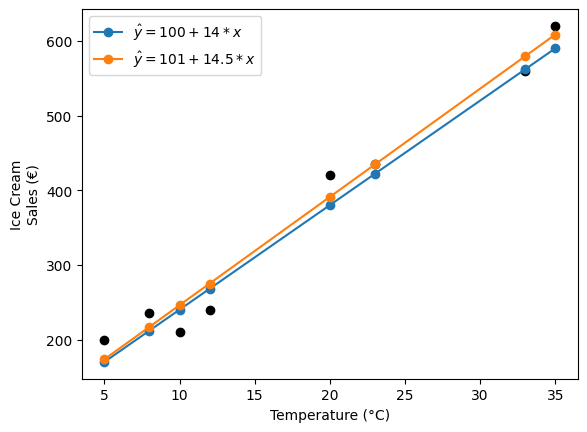

```python
# Predictions 2
y_pred_model_2 = 101 + 14.5 * X
plot_2_models(y_pred, y_pred_model_2)
```

## Metrics

- For estimating the error of our model.
- Two typical ML regression metrics (there are more):
  - Mean Absolute Error (MAE).
  - Mean Squared Error (MSE).

### MAE

- MAE measures the average magnitude of the errors between predicted and observed (real) values.
- $MAE = \frac{1}{N}\sum |{y_i - \hat{y}_i}|$
  - $y_i$ are the observed values (data).
  - $\hat{y}_i$ are the predicted values.
  - $N$ is the number of observations.

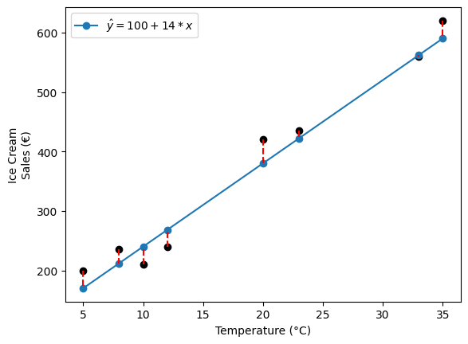

```python
# Predictions Errors
plot_pred_errors()
```

```python
# Absolute error between each pair of observation-prediction
df['abs_error (|y - ŷ|)'] = abs(df['sales (y)'] - df['sales_pred (ŷ)'])
df
```

|  | temp (x) | sales (y) | sales_pred (ŷ) | abs_error (\|y - ŷ\|) |
| --- | --- | --- | --- | --- |
| 0 | 5 | 200 | 170 | 30 |
| 1 | 8 | 235 | 212 | 23 |
| 2 | 10 | 210 | 240 | 30 |
| 3 | 12 | 240 | 268 | 28 |
| 4 | 20 | 420 | 380 | 40 |
| 5 | 23 | 435 | 422 | 13 |
| 6 | 33 | 560 | 562 | 2 |
| 7 | 35 | 620 | 590 | 30 |

```python
# MAE (sum of all elements divided by the length = mean)
mae = df['abs_error (|y - ŷ|)'].mean()
print(f'MAE: {mae} €')
```

```
MAE: 24.5 €
```

For simplicity, we could use a predefined function in `sklearn` for calculating MAE:

```python
from sklearn.metrics import mean_absolute_error

mae = mean_absolute_error(df['sales (y)'], df['sales_pred (ŷ)'])
print(f'MAE: {mae} €')
```

```
MAE: 24.5 €
```

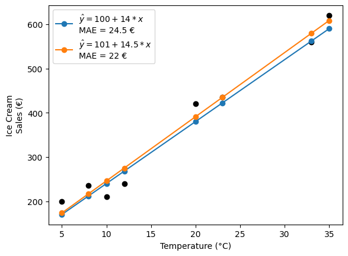

```python
plot_2_models_maes()
```

### MSE

- MSE measures the average of the squares of the errors.
- $MSE = \frac{1}{N}\sum ({y_i - \hat{y}_i})^2$
  - $y_i$ are the observed values (data).
  - $\hat{y}_i$ are the predicted values.
  - $N$ is the number of observations.
- More sensitive to outliers than MAE.

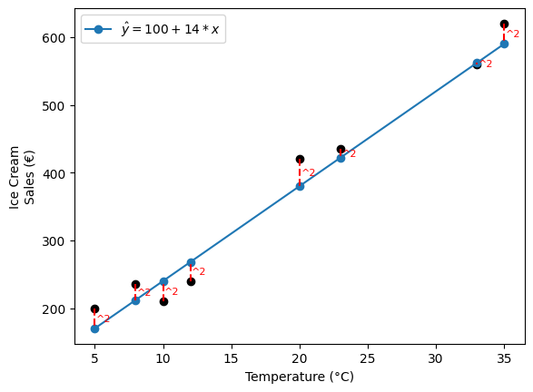

```python
# Predictions Error
plot_data(X, y)
plt.plot(X, y_pred, marker='o', label="$\hat{y} = 100 + 14 * x$")

# Plotting vertical dashed lines
plot_dashed_squared(X, y, y_pred)
plt.legend()
plt.show()
```

```python
# Absolute error between each pair of observation-prediction
df['abs_error_sq ((y - ŷ)²)'] = (df['sales (y)'] - df['sales_pred (ŷ)'])**2
df
```

|  | temp (x) | sales (y) | sales_pred (ŷ) | abs_error (\|y - ŷ\|) | abs_error_sq ((y - ŷ)²) |
| --- | --- | --- | --- | --- | --- |
| 0 | 5 | 200 | 170 | 30 | 900 |
| 1 | 8 | 235 | 212 | 23 | 529 |
| 2 | 10 | 210 | 240 | 30 | 900 |
| 3 | 12 | 240 | 268 | 28 | 784 |
| 4 | 20 | 420 | 380 | 40 | 1600 |
| 5 | 23 | 435 | 422 | 13 | 169 |
| 6 | 33 | 560 | 562 | 2 | 4 |
| 7 | 35 | 620 | 590 | 30 | 900 |

```python
# MSE (sum of all elements divided by the length = mean)
mse = df['abs_error_sq ((y - ŷ)²)'].mean()
print(f'MSE: {mse} €')
```

```
MSE: 723.25 €
```

For simplicity, we could use a predefined function in `sklearn` for calculating MSE:

```python
from sklearn.metrics import mean_squared_error

mse = mean_squared_error(df['sales (y)'], df['sales_pred (ŷ)'])
print(f'MSE: {mse} €')
```

```
MSE: 723.25 €
```

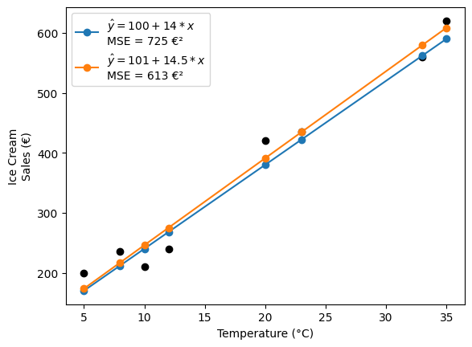

```python
# Plot
plot_data(X, y)
plt.plot(X, y_pred, marker='o', label="$\hat{y} = 100 + 14 * x$\nMSE = 725 €²")
plt.plot(X, y_pred_model_2, marker='o', label="$\hat{y} = 101 + 14.5 * x$\nMSE = 613 €²")
plt.legend()
plt.show()
```

## MAE vs MSE

- MAE:
  - Takes the absolute differences between the actual and predicted values.
  - Gives a linear penalty to each error.
  - Less sensitive to outliers than MSE.
- MSE:
  - Squares the difference between actual and predicted values.
  - Gives a quadratic penalty to the errors.
  - More sensitive to outliers than MAE.
  - Advanced: MSE is smooth and differentiable, suitable for gradient-based optimization methods.
- Let's add an outlier to our previous data.
- Blue model is better than orange with MAE.
- Orange model is better than blue with MSE.

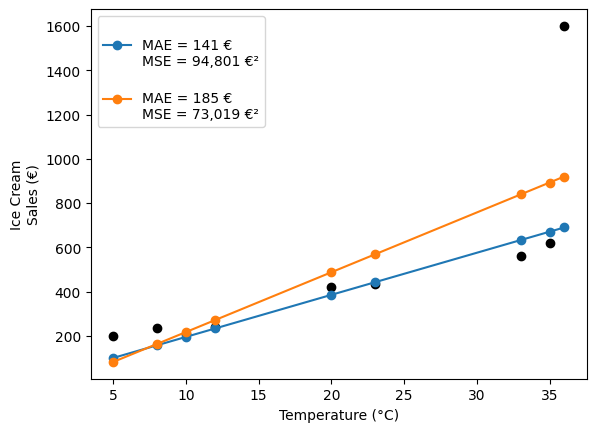

```python
plot_mae_vs_mse()
```

### Which is better?

- It depends.
- Problem Sensitivity:
  - MAE if problem is not sensitive to large errors.
  - MSE if problem is sensitive to large errors.
- Interpretability:
  - MAE in the same units as target.
  - MSE not as interpretable (another option: RMSE).
- Optimization:
  - MSE for problems requiring gradient-based optimization.

## Linear Regression

- Fits a line to the data for making predictions, $\hat{y} = w_0 + w_1 * x$.
- Finds the optimal coefficients $w_0$ and $w_1$ based on a metric.
- Optimized on MSE by default in `sklearn`.
- Considering our initial problem (without the outlier):
  - Best params: $w_0 = 101.61$ and $w_1 = 14.43$

```python
from sklearn.linear_model import LinearRegression

lr = LinearRegression().fit(X, y)
w0 = lr.intercept_
w1 = lr.coef_[0]
print('w0:', round(w0, 2))
print('w1:', round(w1, 2))

y_pred = w0 + w1 * X
```

```
w0: 101.61
w1: 14.43
```

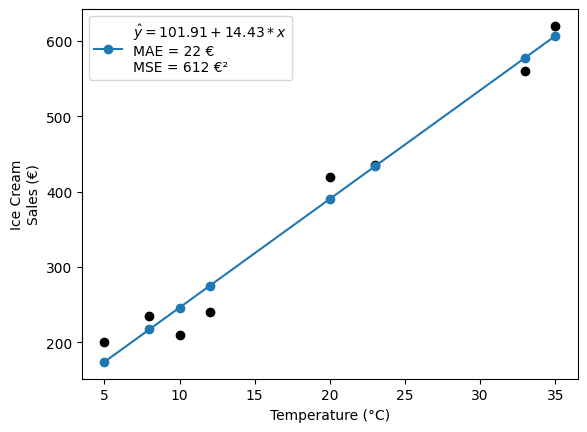

```python
# Predictions

plot_data(X, y)
plt.plot(X, y_pred, marker='o', label="$\hat{y} = 101.91 + 14.43 * x$\nMAE = 22 €\nMSE = 612 €²")
plt.legend()
plt.show()
```

- There is no need to check the values of $w_i$ parameters every time.
- `sklearn` models have a `predict()` function that automatically predicts values based on a trained model.

```python
y_pred = lr.predict(X)
```

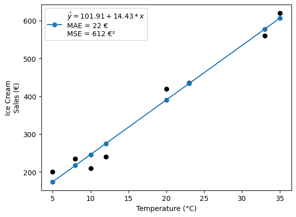

```python
# Predictions

plot_data(X, y)
plt.plot(X, y_pred, marker='o', label="$\hat{y} = 101.91 + 14.43 * x$\nMAE = 22 €\nMSE = 612 €²")
plt.legend()
plt.show()
```

## Quality of Fit

### Overfitting

- There is even a better model for the data!
- Look at this one, with a $MAE = 0$, the perfect model.
- What do you think of it?

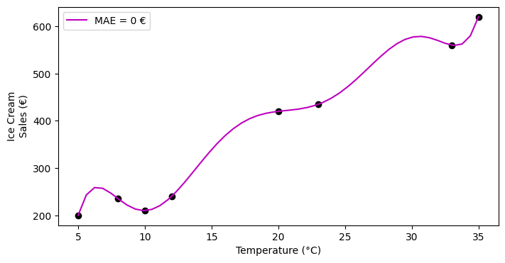

```python
plot_overfit()
```

- We use models for predicting future outcomes.
- When new data arrives, we know if our model is predicting it well or not.
- We can use new information as **test data**,
  - used for evaluating our model's performance on data not seen during training.
- Imagine the new data we receive is:

```python
df_test = pd.DataFrame({
    'temp (x)': [6, 15, 30],
    'sales (y)': [205, 280, 520]
})
df_test
```

|  | temp (x) | sales (y) |
| --- | --- | --- |
| 0 | 6 | 205 |
| 1 | 15 | 280 |
| 2 | 30 | 520 |

- Black dots are the train data.
- Red dots are the test data.
- Polynomial model:
  - Train $MAE = 0 €$.
  - Test $MAE = 55 €$.

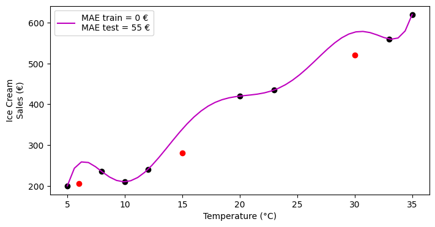

```python
plot_ovefit_test()
```

- Polynomial model:
  - Train $MAE = 0 €$.
  - Test $MAE = 55 €$.
- Our previous linear model:
  - Train $MAE = 22 €$.
  - Test $MAE = 23 €$.

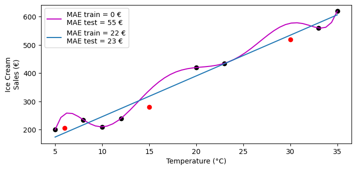

```python
plot_overfit_n_linear()
```

- This effect is called **overfitting**:
  - Our polynomial model is too adapted to the training data.
  - Performance is much better on train data than on test data.
- The linear model performs roughly the same on train and test.
  - The error is not very high.
  - This may be indicating that our model is giving good estimations.

### Underfitting

- Model performs poorly on both train and test data.
- The model is not capturing underlying patterns of the data.

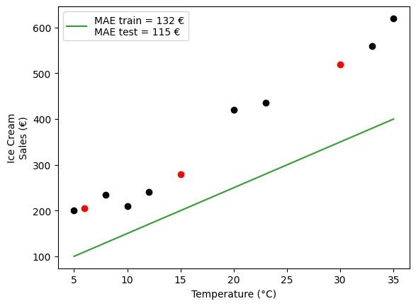

```python
plot_underfit()
```

## Train / Test

- Waiting for new data before evaluating our model would be a waste of time.
- We can emulate unseen data by splitting our data into **train** and **test** sets.
  - Use the train set for fitting our model.
  - Use the test set for evaluating our model's performance
- Usual test sizes are 10-30% of the initial data.
  - Large datasets may require a smaller percentage (e.g., 10-20%).
  - Smaller datasets may need a larger test set to ensure that it is representative (e.g., 30-40%).
  - During cross-validation (see later) test sets can be smaller.

[figure not shown]

Simple ML:

1. Use `train_test_split` from `sklearn` for splitting the data:
   - **X_train**: features used for training the model.
   - **X_test**: features used for testing the model's performance.
   - **y_train**: target for the train.
   - **y_test**: target for the test.
2. Fit a model to the train set.
3. Check model's performance on train and test sets.

```python
from sklearn.model_selection import train_test_split
```

```python
# Using 20% of the data for testing
X_train, X_test, y_train, y_test = train_test_split(X, y, test_size=0.2, random_state=12)
```

```python
# Fit LR to train data (search for the optimal line based on MSE)
lr = LinearRegression().fit(X_train, y_train)

# Predicted values on the test set
y_pred_train = lr.predict(X_train)
y_pred_test = lr.predict(X_test)
```

```python
# Calculate train and test MAE

mae_train = mean_absolute_error(y_train, y_pred_train).round(0).astype(int)
mae_test = mean_absolute_error(y_test, y_pred_test).round(0).astype(int)
```

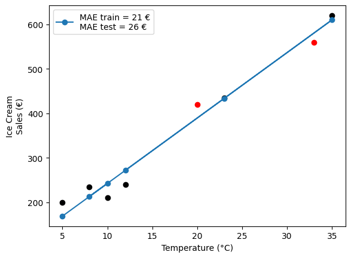

```python
# Predictions

plot_data(X_train, y_train)
plot_data(X_test, y_test, color='r')
plt.plot(X_train, y_pred_train, marker='o', label=f"MAE train = {mae_train} €\nMAE test = {mae_test} €")
plt.legend()
plt.show()
```

## k-Nearest Neighboors

- Let's see another ML algorithm: k-Nearest Neighboors (kNN).
- For the data we want to predict:
  - Take `k` closest points (neighbors) from the training set.
  - Closest points are calculated based on the features.
  - Calculate the averages of their target values $y$.
  - This is the predicted value $\hat{y}$.
- How to determine the number of neighbors `k`?
  - By trying different values and checking their performances.
- What is "closest"?

[figure not shown]

## Parameters

- Internal variables that the algorithm determines during training.
- Learned from the data.
- E.g., Coefficients in LR.

## Hyperparameters

- Parameters not learned from data.
- Must be set before training.
- E.g., The number of neighbors `k` or the distance metric in kNN.

## Data Scaling

- The fact that features may have different scales affect some ML algorithms.
  - E.g., Having as features `temperature` (ºC) and `wind speed` (m/s).
- In kNN, for example, features with different scales affect the distance calculation.
  - Bigger scales have a greater influence on distances.
- LR may be affected by feature scales, but in a very different way than kNN.
  - With scaled features it may find the optimum faster.
  - Without scaled features we cannot infer which ones are more important.
- With data scaling we transform the features so their scales are all similar.
- Typical scaling techniques:
  - Standardization (`sklearn.preprocessing.StandardScaler`): Good for normally distributed data.
  - Min-Max (`sklearn.preprocessing.MinMaxScaler`): Good for bounded data.
  - Robust (`sklearn.preprocessing.RobustScaler`): Good when data contains many outliers.
- We can apply scalings before training a model with `sklearn.pipeline.Pipline`.

```python
from sklearn.neighbors import KNeighborsRegressor
from sklearn.pipeline import Pipeline
from sklearn.preprocessing import MinMaxScaler
```

```python
knn = Pipeline([
    ('scaler', MinMaxScaler()),
    ('model', KNeighborsRegressor(n_neighbors=2)),
])
knn.fit(X_train, y_train)

y_pred_train = knn.predict(X_train)
y_pred_test = knn.predict(X_test)
```

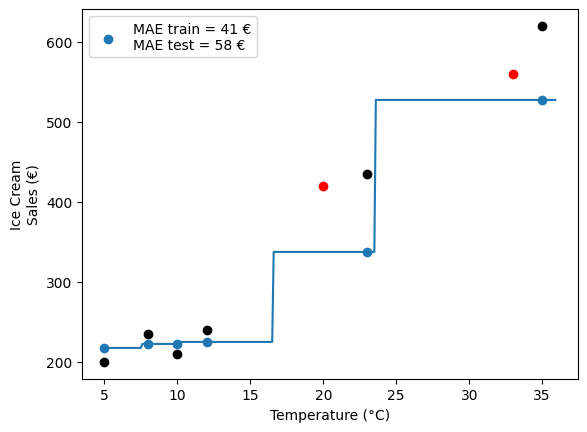

```python
plot_knn_pred()
```

- LR:
  - Train MAE = 21 €.
  - Test MAE = 26 €.
- kNN:
  - Train MAE = 41 €.
  - Test MAE = 58 €.

## Non-linear Data

- Suppose our data looks a bit different than linear.

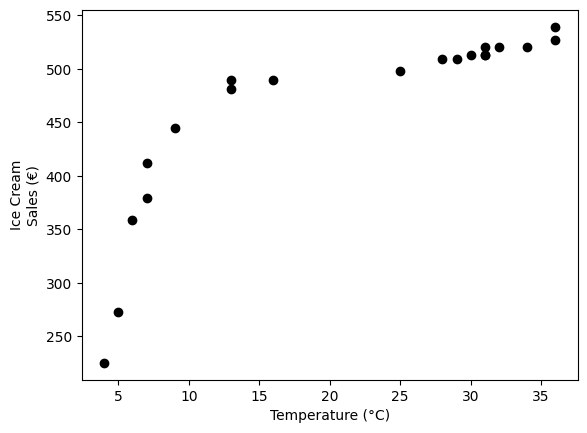

```python
plot_nonlinear()
```

```python
# Using 20% of the data for testing
X_train, X_test, y_train, y_test = train_test_split(X.reshape(-1, 1), y, test_size=0.2, random_state=12)
```

### Linear Regression

- Difficult to make good predictions by fitting a straight line to non-linear data.

```python
# Train
lr = LinearRegression()
lr.fit(X_train, y_train)

# Predict
y_pred_train = lr.predict(X_train)
y_pred_test = lr.predict(X_test)

# Error
mae_train = mean_absolute_error(y_train, y_pred_train).round(0).astype(int)
mae_test = mean_absolute_error(y_test, y_pred_test).round(0).astype(int)
```

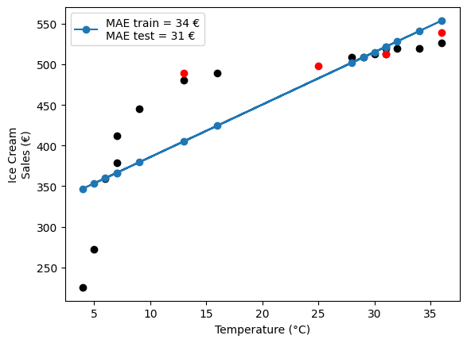

```python
plot_nonlinear_lr()
```

### kNN

- Adapts better to non-linearities.

```python
# Train
knn = KNeighborsRegressor(n_neighbors=3)
knn.fit(X_train, y_train)

# Predict
y_pred_train = knn.predict(X_train)
y_pred_test = knn.predict(X_test)

# Error
mae_train = mean_absolute_error(y_train, y_pred_train).round(0).astype(int)
mae_test = mean_absolute_error(y_test, y_pred_test).round(0).astype(int)
```

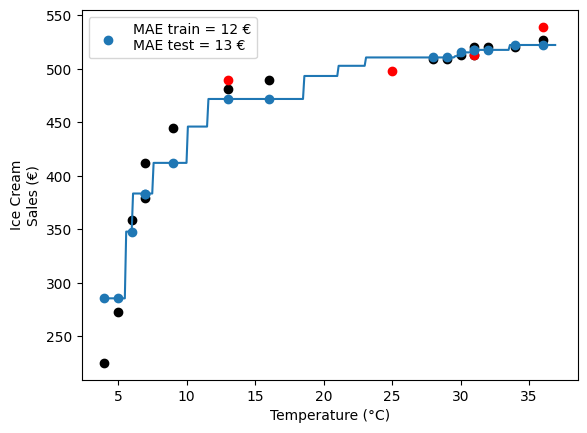

```python
plot_nonlinear_knn()
```

- LR:
  - Train MAE = 34 €.
  - Test MAE = 31 €.
- kNN:
  - Train MAE = 12 €.
  - Test MAE = 13 €.

## LR vs kNN

- Linear Regression:
  - **Parametric**: Assumes a linear distribution of the data, so it is less flexible.
  - **Speed**: Faster to train and predict because it has fewer parameters.
  - **Interpretability**: Provides coefficients that can be used as features importances.
  - **Linear Decision**: Works well when the relationship between features and output is linear.
- k-Nearest Neighbors:
  - **Non-Parametric Model**: Makes no assumptions about the data distribution, allowing for greater flexibility.
  - **Slower**: Computationally expensive and slow with large datasets.
  - **Harder to Interpret**: Difficult to interpret the model.
  - **Complex**: Can model complex relations between features and targets.

## Cross-validation

- Problems with a single Train/Test spit:
  - Limited use of data.
  - Variability in model performance.
  - Risk of selecting a model "overfit" with train and test data.
- For overcoming these limitations a common technique is to apply **cross-validation** with the **training** set:
  - Divide data into $k$ folds/parts.
  - Train a model with ($k - 1$) folds.
  - Validate on remaining fold
  - Repeat $k$ times with different combinations of training folds.
  - Average performance metrics.

[figure not shown]

```python
from sklearn.model_selection import KFold, cross_validate
from sklearn.metrics import mean_squared_error, mean_absolute_error, make_scorer
```

```python
# Initialize KFold cross-validator
kf = KFold(n_splits=5, shuffle=True, random_state=42)
```

```python
# Declare scores to be used
scoring = {
    'MSE': make_scorer(mean_squared_error),
    'MAE': make_scorer(mean_absolute_error),
}
```

```python
# kNN algorithm
knn = KNeighborsRegressor(n_neighbors=3)

# Train 5 models with different splits of the data
# and test the performance with the remaining split at each iteration
cv_results = cross_validate(knn, X_train, y_train, cv=kf,
                            scoring='neg_mean_absolute_error',
                            return_train_score=True)
```

[output not shown]

```python
# Display info
print("Train MAE:", knn_cv['train_MAE'].round(2))
print("Validation MAE:", knn_cv['test_MAE'].round(2))
print()
print("Avg Train MAE:", knn_cv['train_MAE'].mean().round(2), "€")
print("Avg Validation MAE:", knn_cv['test_MAE'].mean().round(2), "€")
```

[output not shown]

Use the same method for measuring the performance with other hyperparameter values:

```python
# kNN algorithm
knn = KNeighborsRegressor(n_neighbors=2)

# Train 5 models with different splits of the data
# and test the performance with the remaining split at each iteration
knn_cv = cross_validate(knn, X_train, y_train, cv=kf,
                        scoring=scoring, return_train_score=True)
```

```python
# Display info
print("Train MAE:", knn_cv['train_MAE'].round(2))
print("Validation MAE:", knn_cv['test_MAE'].round(2))
print()
print("Avg Train MAE:", knn_cv['train_MAE'].mean().round(2), "€")
print("Avg Validation MAE:", knn_cv['test_MAE'].mean().round(2), "€")
```

```
Train MAE: [14.11 10.41 11.2   9.42 13.44]
Validation MAE: [15.92 33.45  5.9  19.82 36.52]

Avg Train MAE: 11.72 €
Avg Validation MAE: 22.32 €
```

After we are happy with one of the models:

- Retrain it with the whole training set.
- Check performance on test set.

```python
# kNN algorithm
knn = KNeighborsRegressor(n_neighbors=2)

# Train
knn.fit(X_train, y_train)

# Predictions
y_pred_train = knn.predict(X_train)
y_pred_test = knn.predict(X_test)

# Error
mae_train = mean_absolute_error(y_train, y_pred_train).round(0).astype(int)
mae_test = mean_absolute_error(y_test, y_pred_test).round(0).astype(int)

# Display results
print(f"Train MAE: {mae_train} €")
print(f"Test MAE: {mae_test} €")
```

```
Train MAE: 9 €
Test MAE: 9 €
```

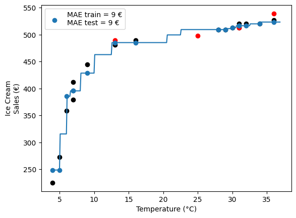

```python
plot_nonlinear_knn_preds()
```

## Beyond 1 Feature

- So far, visualizing everything with 1 feature was easy.
- In real life we very rarely have 1 feature.
- We could have up to millions of features.

### 2 Features

- Imagine we add another feature to our initial data: `wind` (in km/h).
- Now with `temperature` and `wind` as features we want to predict `sales`.
- Still easy to visualize in 3D.

```python
df2
```

[output not shown]

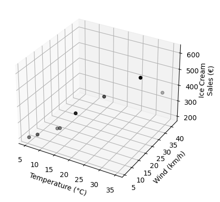

```python
plot_3d_data(df2['temp (x1)'], df2['wind (x2)'], df2['sales (y)'])
plt.show()
```

- We can also visualize the models given by LR or kNN.
- For LR, we have a plance instead of a line, with an equation of the form:
  - $\hat{y} = w_0 + w_1 * x_1 + w_2 * x_2$, where
    - $x_1$ is the temperature.
    - $x_2$ is the wind speed.
  - Now Linear Regression finds the optimal $w_0$, $w_1$ and $w_2$ parameters.

```
Equation: ŷ = 155.12 + 18.38 * x1 + -9.27 * x2
```

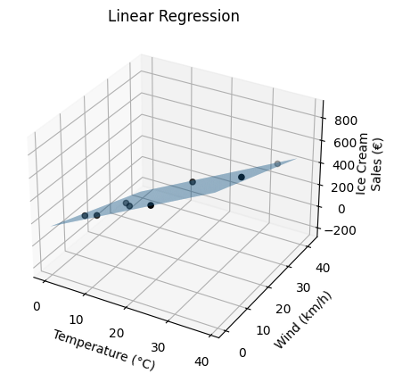

```python
plot_3d_plane()
```

### Multiple Features

- With more than 2 features it is not possible to directly visualize it.
- There are some techniques, but they are not part of this course (or bonus).
- We have to trust the values given by our metrics.

## Summary

1. Clean and preprocess data.
2. Decide which **metrics** are better for our problem, e.g., **MAE** or **MSE**.
3. Divide data into **train** and **test** sets.
4. Decide which algorithms to use for modeling the training data, e.g., **LR** or **kNN**.
5. Make sure to apply feature **scaling** if the algorithms require so.
6. With the training data, apply **cross-validation** for each of the algorithms and their respective **hyperparameters**.
   - Be careful with **overfitting** and **underfitting**.
7. Choose the best performing 2 or 3 models based on the cross-validation performance.
8. Check the performance of those models on the test set.
   - Be careful with overfitting and underfitting.
9. Keep the best model or go back to the previous step if the performance is not good.